# Problem Set 1

Note that you need to show your work. There are five questions in total.

1. This is a revision for equation of a line. Consider the following two variables “X” and “Y.”

| X | Y |
| --- | --- |
| 20 | 60 |
| 22 | 64 |
| 24 | 68 |
| 26 | 72 |
| 28 | 76 |
| 30 | 80 |
| 32 | 84 |
| 34 | 88 |
| 36 | 92 |
| 38 | 96 |
| 40 | 100 |

We are concerned with expressing y, as y = mx + c, where y and x are the “Y” and “X” variables, respectively; m is the slope, and c is the y intercept.

1. Find m and c.
2. Write down the equation of the line describing the relationship between “X” and “Y” and plot the line on a graph.
3. Now say that “X” is increased by 20. So, basically you are adding the Column “X” with 20. How would this affect the equation of the line b? Plot the new line along with the one you have for part b.
2. Now consider a new set of “x” and “y” points, whose relationship is depicted in Figure 1.

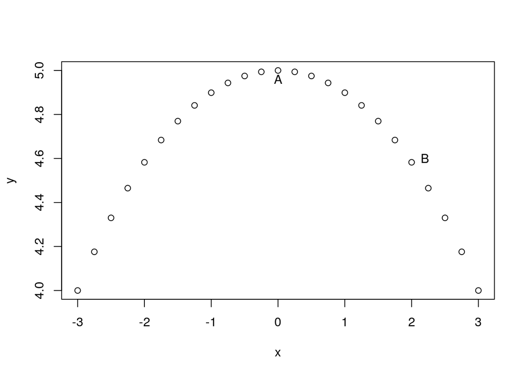

   Figure 1.
1. Draw a tangent line across point A. Calcualte the slope of a tangent line that goes across the point A.
2. Draw a tangent line across point B. Approximate the slope of the tangent line that goes across the point B.
3. What remark can you make between the slope of the line vs. the slope of the curve?
4. Find the equation of the curve shown in Figure 1.
3. **Working with income data.** Download the spreadsheet data [here](https://tinyco.re/7444763). Choose five countries that you are interested in, then note the names of the countries.
1. For each one calculate the 90/10 ratio in 1980, 1990 and 2014.
2. Describe the differences between countries and the changes over time that you find.
3. Can you think of any explanations for them?
4. Consider the following production schedule.

| name | Production if 100% of time is spent on one good |
| --- | --- |
| Greta | 1,250 apples or 50 tonnes of wheat |
| Carlos | 1,000 apples or 20 tonnes of wheat |

1. Draw the production possibility frontier (ppf) for Greta and Carlos. Note that ppf shows the combination of apples and wheat Greta can produce (same with Carlos).
2. Is the slope of the ppf constant?
3. Who has the absolute advantage in both crops? Show work. Explain.
4. Who has the comparative advantage in growing apples? Show work. Explain.
5. Who has the comparative advantage in growing wheat? Show work. Explain.
6. What are some drawbacks of specialization?
5. This will provide a technical guide as to solve question 3.

Consider the income of 10 individuals are below.

| person | income |
| --- | --- |
| A | 30680.151 |
| B | 67797.937 |
| C | 38200.300 |
| D | 26585.310 |
| E | 0.000 |
| F | 31926.852 |
| G | 66298.121 |
| H | 63970.405 |
| I | 9348.271 |
| J | 50840.253 |

1. Arrange income in an ascending order and find the 20 and 80 percentiles of income. Note that
   $$\tau^{th}$$
   percentile, as given by
   $$x_{\tau}$$
   , is such that
   $$P(X\leq x_{\tau})=\tau$$
   , where
   $$X$$
   is a random variable, e.g. income.
2. Then find 80/20 ratio. hint: after you have found the 20 percentile, find the average income below the 20th percentile. Do the same for the 80th percentile. Then,
   $$80/20\;ratio = \frac{average\;income\;above\;80^{th}\;percentile}{average\;income\;below\;20^{th}\;percentile}$$
   .